```python
spark = spark.builder.appName("Image").getOrCreate()
```

```
Starting Spark application
```

| ID | YARN Application ID | Kind | State | Spark UI | Driver log | Current session? |
| --- | --- | --- | --- | --- | --- | --- |
| 1 | application_1573796988281_0002 | pyspark | idle | [Link](http://ip-172-40-0-132.us-west-2.compute.internal:20888/proxy/application_1573796988281_0002/) | [Link](http://ip-172-40-0-37.us-west-2.compute.internal:8042/node/containerlogs/container_1573796988281_0002_01_000001/livy) | ✔ |

```
SparkSession available as 'spark'.
```

```python
#install need python libraries on this cluster
sc.install_pypi_package("pandas")
sc.install_pypi_package("matplotlib")
```

## Get Data from S3

The data resides in the S3 bucket under the valid path. In valid, there's sub directories for each classification. Pass wildcard for spark to read images nested in those directories

```python
input_path = 's3://chexpert-small-dataset/valid/*/*.jpg'
```

```python
df = spark.read.format("image").load(input_path)
```

```python
df.count()
```

```
1720
```

```python
df.show()
```

```
+--------------------+
|               image|
+--------------------+
|[s3://chexpert-sm...|
|[s3://chexpert-sm...|
|[s3://chexpert-sm...|
|[s3://chexpert-sm...|
|[s3://chexpert-sm...|
|[s3://chexpert-sm...|
|[s3://chexpert-sm...|
|[s3://chexpert-sm...|
|[s3://chexpert-sm...|
|[s3://chexpert-sm...|
|[s3://chexpert-sm...|
|[s3://chexpert-sm...|
|[s3://chexpert-sm...|
|[s3://chexpert-sm...|
|[s3://chexpert-sm...|
|[s3://chexpert-sm...|
|[s3://chexpert-sm...|
|[s3://chexpert-sm...|
|[s3://chexpert-sm...|
|[s3://chexpert-sm...|
+--------------------+
only showing top 20 rows
```

From the databricks Spark docs found [here](https://docs.databricks.com/data/data-sources/image.html)

Image files are loaded as a DataFrame containing a single struct-type column called image with the following fields:

```
image: struct containing all the image data
  |-- origin: string representing the source URI
  |-- height: integer, image height in pixels
  |-- width: integer, image width in pixels
  |-- nChannels
  |-- mode
  |-- data
```

### Accessing the data

The Data Frame contains rows of structs as noted above. One Row contains one column of the struct, where each element of the struct is accesed via its attribute name. This is similar with Scala Spark using Case Classes. If We take 1 element of the Data Frame, Spark returns a "Row" list, with one row of data

```python
df.take(1)
```

```
[Row(image=Row(origin='s3://chexpert-small-dataset/valid/Enlarged_Cardiomediastinum/frontal_424.jpg', height=320, width=320, nChannels=1, mode=0, data=bytearray(b'\xca\xff\xec\x17\x18\x16\x15\x18g\xc7\xfd\xef\xfd\xff\xed\xfe\x9d\x97\xf5\xab\xff\xff\xff\xce\xe8\xaa\xff\xfe\xff\xfe\xff\xff\xff\x94\x17…
```

since it is a list of one row, we have to select the 0th element of the list to get to the struct

```python
df.take(1)[0]
```

```
Row(image=Row(origin='s3://chexpert-small-dataset/valid/Enlarged_Cardiomediastinum/frontal_424.jpg', height=320, width=320, nChannels=1, mode=0, data=bytearray(b'\xca\xff\xec\x17\x18\x16\x15\x18g\xc7\xfd\xef\xfd\xff\xed\xfe\x9d\x97\xf5\xab\xff\xff\xff\xce\xe8\xaa\xff\xfe\xff\xfe\xff\xff\xff\x94\x17\…
```

Now that we have accessed the row element, we can access the "image" struct and any of its attributes by calling them. To get the height and width of the image:

```python
row = df.take(1)[0]
height = row.image.height
width = row.image.width

print('Height: {}'.format(height))
print('Width: {}'.format(width))
```

```
Height: 320
Width: 320
```

### Image

The image itself, is referenced as the **data** attribute. When read in by Spark, it is converted to a byte array. In order to preprocess the images with histogram equalization and resizing, the images need to be converted back to a numpy array first.

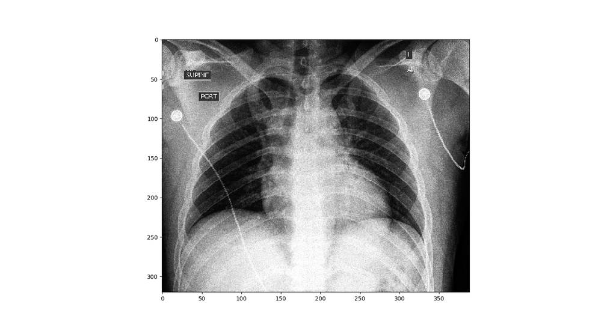

```python
from pyspark.ml.image import ImageSchema
import matplotlib.pyplot as plt
import numpy as np

#sample 1 image random image
image_struct = df.take(3)[1].image
#conver the spark ImageSchema to a numpy array
img = ImageSchema.toNDArray(image_struct)

#plot image
plt.figure(figsize=(15,8))
plt.imshow(np.squeeze(img), cmap='gray')
%matplot plt
```